# Shark Attack Data Analytics: Exploration on Environment Variables

The influence of environmental variables on the presence of white sharks can be found from the article, http://www.ncbi.nlm.nih.gov/pmc/articles/PMC3712984/. White sharks have been implicated in 346 unprovoked attacks on humans worldwide, of which 102 were fatal since 1839, with a steady increase in the frequency of attacks.

This project targets all the attacks by different species of sharks. The main goal of the data exploration is to retrieve sea surface temperature (SST) from the NOAA web site, which hosts 36 files storing data from 1981 to 2016. Each file (~450 MB) stores daily mean SST each year. The stark attack dataset provides the attack location, area, and country, which are used for the conversion to (latitude, longitude) coordinate via google API. Some locations were not recorded correctly or accurately, so manual correction was required. Via visualizing the attack locations marked on the map, we can further clean erroneous data points. The temperature (SST) is one of explanatory variables in the shark attack data analytics.

## Data set

The following data sets are provided to analyze Shark Attack.

```r
# http://www.huffingtonpost.com/norm-schriever/coming-down-from-shark-we_b_3740495.html
suppressMessages(library(readr))
suppressMessages(library(tidyr))
suppressMessages(library(plyr))
suppressMessages(library(dplyr))
suppressMessages(library(ggplot2))
suppressMessages(library(lubridate))
# attack location, how many people in the area, water realted env variables, date, time
SAdata <- read_csv("Shark_Attack_Data_4-7-2016.csv",col_names=TRUE,n_max=5897)
SharkSpecies <- tbl_df(read_csv("Shark_Species_Data_4-7-2016.csv"))
Sharks <- read_csv("Sharks_4-7-2016.csv")
```

## Analyze area, location, and country

Note that “Unprovoked attacks” are defined as incidents where an attack on a live human occurs in the shark’s natural habitat with no human provocation of the shark. No matter the incident was provoked or unprovoked, there were more than 2000 cases occurred in USA. The section of R code is as follows for country ranking of shark attacks.

```r
SA_tab <- tbl_df(SAdata[1:19])
colnames(SA_tab)[1] <- "CaseNumber"
SA_tab %>% select(CaseNumber,Date,Year,Location,Area,Country) %>%
  group_by(Location,Area,Country) %>% dplyr::summarize(n=n()) %>%
  filter(is.na(Area)) %>% View()
SA_tab %>% group_by(Country) %>% select(CaseNumber,Date,Year,Area) %>%
  dplyr::summarize(n=n()) %>% arrange(desc(n))
```

```
## Source: local data frame [197 x 2]
##
##             Country     n
##               (chr) (int)
## 1               USA  2063
## 2         AUSTRALIA  1263
## 3      SOUTH AFRICA   563
## 4  PAPUA NEW GUINEA   133
## 5       NEW ZEALAND   124
## 6            BRAZIL   102
## 7           BAHAMAS    94
## 8            MEXICO    82
## 9             ITALY    71
## 10             FIJI    62
## ..              ...   ...
```

## Visualization of shark attack locations

The world map and the US map are required in order to show the locations of shark attacks. Map tools were explored and selected for the study.

### Loading map tools

A section of geocoding code to retrieve (lat,lon) coordinates using Google API.

```r
#### This script uses RCurl and RJSONIO to download data from Google's API:
#### Latitude, longitude, location type (see explanation at the end), formatted address
#### Notice ther is a limit of 2,500 calls per day
suppressMessages(library(bitops))
suppressMessages(library(RCurl))
suppressMessages(library(RJSONIO))

url <- function(address, return.call = "json", sensor = "false") {
 root <- "http://maps.google.com/maps/api/geocode/"
 u <- paste(root, return.call, "?address=", address, "&sensor=", sensor, sep = "")
 return(URLencode(u))
}

geoCode <- function(address,verbose=FALSE) {
 if(verbose) cat(address,"\n")
 u <- url(address)
 doc <- getURL(u)
 x <- fromJSON(doc,simplify = FALSE)
 if(x$status=="OK") {
 lat <- x$results[[1]]$geometry$location$lat
 lng <- x$results[[1]]$geometry$location$lng
 location_type <- x$results[[1]]$geometry$location_type
 formatted_address <- x$results[[1]]$formatted_address
 return(c(lat, lng, location_type, formatted_address))
 } else {
 return(c(NA,NA,NA, NA))
 }
}
```

### Worldside shark attacks

The google API has the limitation of 2500 queries per day. Therefore, the queries were run three times on three machines. Three files (.rds) were created to save the results, and then read back to a data frame. Manual corrections were performed for inaccurate or incorrect location inputs. The correction was only made for USA, which is the country selected for data analysis. Obviously there are more corrections needed for other countries based on the world attack map.

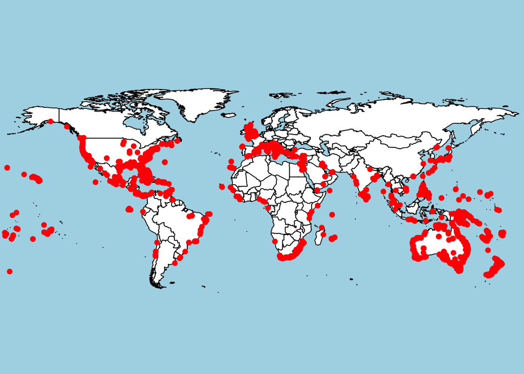

```r
world_tab <- SA_tab %>% select(CaseNumber,Location,Area,Country,Date) %>% na.omit()
address <- do.call(paste, c(select(world_tab,-c(CaseNumber,Date)), sep=" ")) %>%
              iconv(from="CP1252",to="UTF-8")

# run and then save the result---there are 2500 queries limitation per day
#infile <- "world_lon-lat_SAdata-5033to5217.rds"
#locations <- sapply(address[5033:5217],geocode)
#saveRDS(locations, infile)

# read in (lon,lat) from three .rds files
infile <- "world_lon-lat_SAdata-1to2532.rds"
read_loc <- t(readRDS(infile))
read_df <- data.frame(world_tab$CaseNumber,matrix(unlist(read_loc),
                                                  nrow=dim(read_loc)[1]))
names(read_df) <- c("CaseNumber","lon","lat")

infile <- "world_lon-lat_SAdata-2533to5032.rds"
read_loc <- t(readRDS(infile))
read_df[2533:5217,2:3] <-data.frame(matrix(unlist(read_loc),nrow=dim(read_loc)[1]))

infile <- "world_lon-lat_SAdata-5033to5217.rds"
read_loc <- t(readRDS(infile))
read_df[5033:5217,2:3] <-data.frame(matrix(unlist(read_loc),nrow=dim(read_loc)[1]))

# Fixed the following locations manually
Inland <- SA_tab %>% filter(Area=="Guam")
read_df[which(read_df$CaseNumber==Inland$CaseNumber),2:3] <- c(144.76,13.48)
# one incident inland is Albuquerque aquarium, Albuquerque, NM
# 6 incidents inland are California, CA
# one incident occurred in Destin, Okaloosa County, FL
Inland <- SA_tab[grep("Destin",SA_tab$Location),]
read_df[which(read_df$CaseNumber %in% Inland$CaseNumber)[1],2:3] <- c(-86.5,30.39)
# one incident in 15 miles south of Jones Inlet, which is actually in Long Island
Inland <- SA_tab[grep("Jones Inlet",SA_tab$Location),]
read_df$lon[which(read_df$CaseNumber%in%Inland$CaseNumber)] <- -73.13
read_df$lat[which(read_df$CaseNumber%in%Inland$CaseNumber)] <- 40.79
# one incident in Sandbridge beach, VA
Inland <- SA_tab[grep("Sandbridge Beach",SA_tab$Location),]
read_df[which(read_df$CaseNumber==Inland$CaseNumber),2:3] <- c(-75.94,36.72)
# one incident in Gun Beach, Guam
Inland <- SA_tab[grep("Gun Beach",SA_tab$Location),]
read_df[which(read_df$CaseNumber==Inland$CaseNumber),2:3] <- c(144.8,13.52)
# one incident in Short sand beach
Inland <- SA_tab[grep("Short Sand Beach",SA_tab$Location),]
read_df[which(read_df$CaseNumber==Inland$CaseNumber),2:3] <- c(-123.87,45.76)
# one incident in Catalina Island, CA
Inland <- SA_tab[grep("West Cove, Catalina Island",SA_tab$Location),]
read_df[which(read_df$CaseNumber==Inland$CaseNumber),2:3] <- c(-118.42,33.39)
# one incident in 24 km off Santa Catalina Island in the Channel Islands
Inland <- SA_tab[grep("24 km off Santa Catalina Island",
                      SA_tab$Location),]
read_df[which(read_df$CaseNumber==Inland$CaseNumber),2:3] <-
  c(-118.42,33.3833)
# one incident in Hanalei Bay, FL actually in St. George Island
Inland <- SA_tab[grep("Hanalei Bay",
                      SA_tab$Location),] %>% filter(Area=="Florida")
read_df[which(read_df$CaseNumber==Inland$CaseNumber),2:3] <-
  c(-84.88,29.66)
# one incident in A quarter mile north of Fort Pierce Inlet Florida
Inland <- SA_tab[grep("A quarter mile north of Fort Pierce Inlet",
                      SA_tab$Location),]
read_df[which(read_df$CaseNumber==Inland$CaseNumber),2:3] <-
  c(-80.3164,27.5317)
# one incident in Curlew Island, Breton Sound, LA
Inland <- SA_tab[grep("Curlew Island, Breton Sound",
                      SA_tab$Location),]
read_df[which(read_df$CaseNumber==Inland$CaseNumber),2:3] <-
  c(-88.9686,29.6466)
# one incident in Midnight Lump, LA
Inland <- SA_tab[grep("Midnight Lump",
                      SA_tab$Location),]
read_df[which(read_df$CaseNumber==Inland$CaseNumber),2:3] <-
  c(-89.3341,28.3825)
# Dog Patch, San Onofre, CA is actually San Onofre State Beach
Inland <- SA_tab[grep("Dog Patch, San Onofre",
                      SA_tab$Location),]
read_df[which(read_df$CaseNumber==Inland$CaseNumber),2:3] <-
  c(-117.5731,33.3811)
# Bird Rock, Tomales Point, CA
Inland <- SA_tab[grep("Bird Rock, Tomales Point",
                      SA_tab$Location),] %>% filter(Year==1996)
read_df[which(read_df$CaseNumber==Inland$CaseNumber),2:3] <-
  c(-122.9944,38.23)
# Ano Nuevo State Reserve, Davenport County, CA
Inland <- SA_tab[grep("Ano Nuevo State Reserve, Davenport County",
                      SA_tab$Location),]
read_df[which(read_df$CaseNumber%in%Inland$CaseNumber),2:3] <-
  c(-122.3066,37.1188)
# Southeast Farallon Island, Farallon Islands, CA is actually San Onofre State Beach
Inland <- SA_tab[grep("Southeast Farallon Island",
                      SA_tab$Location),]
read_df$lon[which(read_df$CaseNumber%in%Inland$CaseNumber)] <- -123.0034
read_df$lat[which(read_df$CaseNumber%in%Inland$CaseNumber)] <- 37.69891
# Monastery Beach, Carmel River State Park, Monterey Peninsula, Monterey, CA
Inland <- SA_tab[grep("Monastery Beach, Carmel River State Park",
                      SA_tab$Location),]
read_df[which(read_df$CaseNumber==Inland$CaseNumber),2:3] <-
  c(-121.9268,36.5236)
# North Farallon Island, Farallon Islands, CA
Inland <- SA_tab[grep("North Farallon Island, Farallon Islands",
                      SA_tab$Location),]
read_df[which(read_df$CaseNumber==Inland$CaseNumber),2:3] <-
  c(-123.09912,37.7676)
# Klamath River, Del Norte County, CA is actually the Klamath River mouth around Requa
Inland <- SA_tab[grep("Klamath River, Del Norte County",
                      SA_tab$Location),]
read_df$lon[which(read_df$CaseNumber %in% Inland$CaseNumber)] <- -124.0653
read_df$lat[which(read_df$CaseNumber %in% Inland$CaseNumber)] <- 41.5469

# plot world map
map("world", fill=TRUE, col="white", bg="lightblue",
    ylim=c(-60, 90), mar=c(0,0,0,0))
read_df <- read_df %>% na.omit()
points(read_df$lon,read_df$lat, col="red", pch=16)
```

```r
# old approach - seems not working
#locations <- ldply(address,
#                   function(x) geoCode(x))
# loc <- data.frame(world_tab$CaseNumber,world_tab$Date,t(locations)) %>%
#  na.omit()
#colnames(loc) <- c("CaseNumber","day","lat","lon","location_type",
#                   "forAddress")

#map("world", fill=TRUE, col="white", bg="lightblue", ylim=c(-60, 90), mar=c(0,0,0,0))
#points(as.numeric(loc$lon),as.numeric(loc$lat), col="red", pch=20)
```

### Shark attacks in USA

Let’s plot the shark attacks in USA. Note that the one far inland was the incident at Alberquerqy aquarium in New Mexicao.

First, compute kmeans clusters.

```r
USA_tab <- SA_tab %>% filter(Country=="USA") %>% left_join(read_df) %>% na.omit()
USA_tab$clusterID <- kmeans(USA_tab[c("lon","lat")],4)$cluster
```

A summary table listing number of shark attacks ocurred in each state is given in the following.

```r
suppressMessages(library(sp))
suppressMessages(library(rgdal))

#lat and long
coords <- USA_tab %>% select(lon,lat) %>% as.matrix()
points <- SpatialPoints(coords)

#SpatialPolygonDataFrame - I'm using a shapefile of USA
usa.states <- readOGR(dsn="states_21basic", layer="states")
```

```r
#my_state <- usa.states[usa.states$STATE_NAME == "Texas", ]
#plot(my_state)

#assume same proj as shapefile!
proj4string(points) <- proj4string(usa.states)
#get county polygon point is in
result <- as.data.frame(table(tolower(as.character(over(points, usa.states)$STATE_NAME))))
colnames(result) <- c("state","count")
result
```

```
##             state count
## 1      california    76
## 2        delaware     2
## 3         florida   167
## 4          hawaii    77
## 5       louisiana     1
## 6        maryland     1
## 7      new jersey     2
## 8      new mexico     1
## 9        new york     4
## 10 north carolina    10
## 11         oregon    16
## 12 south carolina    26
## 13          texas     8
## 14       virginia     2
```

Two representations of attack occurence in each state are plotted: (1) dense color vs. light color, and (2) color by cluster ID.

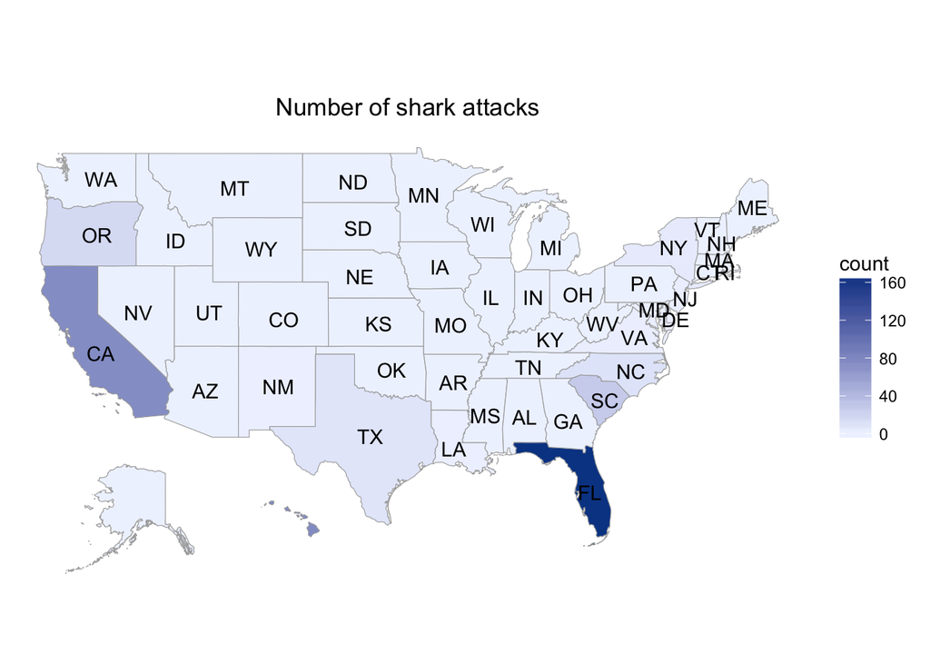

```r
# plot attack locations based on cluster ID
suppressMessages(library(choroplethr))
suppressMessages(library(choroplethrMaps))

data(state.regions)
df_state_count <- state.regions %>% left_join(result,by=c("region"="state")) %>%
  mutate(value=ifelse(is.na(count),0,count)) %>% select(region,value)
state_choropleth(df_state_count, title="Number of shark attacks",
                 legend = "count", num_colors=1)
```

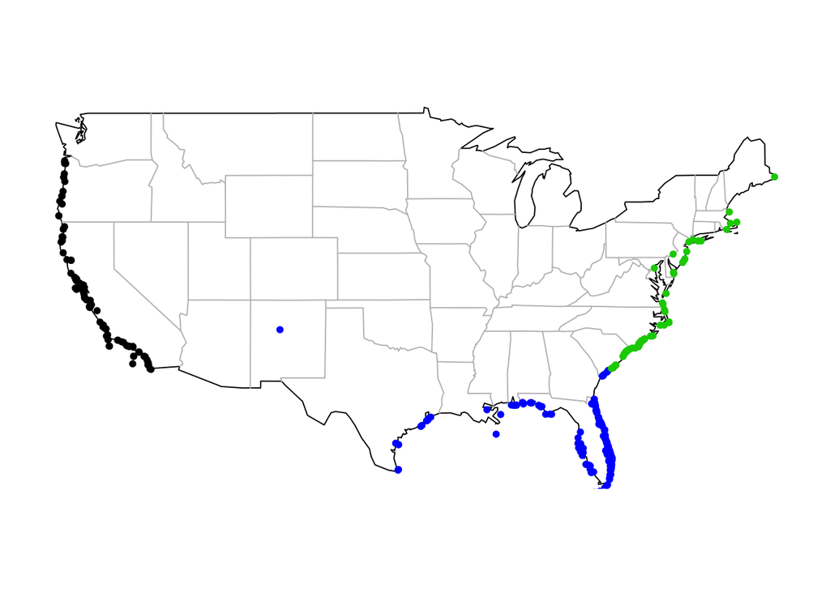

```r
# color by cluster ID
map("state", interior = FALSE)
map("state", boundary = FALSE, col="gray", add = TRUE)
points(USA_tab$lon, USA_tab$lat, col=USA_tab$clusterID, pch=20)
```

## World Ocean Database

### Download NOAA sea temperatures files in the format of ncdf4

Retrieve the daily mean of sea surface temperature and plot the distribution on the world map.

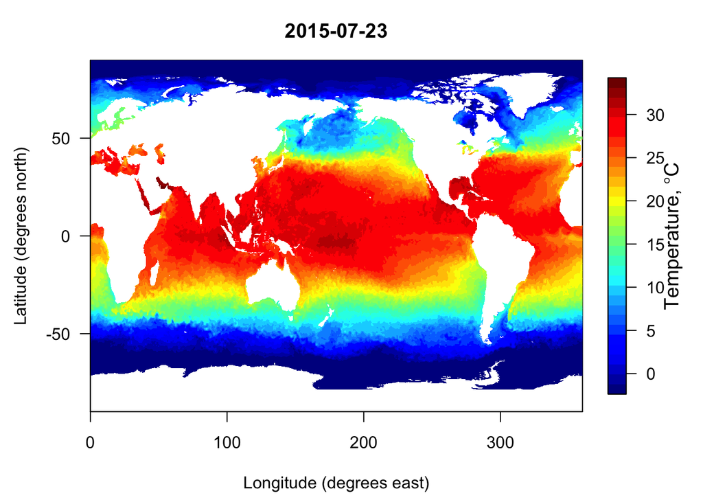

### Data retrieval

Apply the algorithm, which is designed to extend the area (5 degrees in each direction) in case a NA value is returned for a specific location, to the shark attack data. Mean value is calculated from all the values in the extension area. Temperature values with respect to each attack incident are saved to a file provided for data analytics.

```r
mean_temp <- function(loc) {
  lon <- as.numeric(loc[2])
  lat <- as.numeric(loc[3])
  day <- as.Date(loc[1])
    lonarg <- c(floor(lon),ceiling(lon))
    latarg <- c(floor(lat),ceiling(lat))
    ssts = extractOISSTdaily(
                paste0("daily/sst.day.mean.",year(day),".v2.nc"),
                   "daily/lsmask.oisst.v2.nc",
                   lonW=lonarg[1],lonE=lonarg[2],
                    latS=latarg[1],latN=latarg[2],
                         date1=day)
    while(all(is.na(ssts))) {
      lonarg <- lonarg + c(-1,1)*5
      latarg <- latarg + c(-1,1)*5
      ssts = extractOISSTdaily(
             paste0("daily/sst.day.mean.",year(day),".v2.nc"),
                   "daily/lsmask.oisst.v2.nc",
                   lonW=lonarg[1],lonE=lonarg[2],
                    latS=latarg[1],latN=latarg[2],
                         date1=day)
    }
    with_value <- !is.na(ssts)
    mean(ssts[with_value])
}
# remove words after year, before date, convert to 2-digit year
USA_tab$Date<- gsub ("([0-9]*)\\.(.*)$","\\1",USA_tab$Date)
USA_tab$Date <- gsub("(^\\w*\\s*)\\d","1",USA_tab$Date)
USA_tab$Date <- gsub("(.*)-(..)(..)$", "\\1-\\3", USA_tab$Date)

# fixing year 0-68 --> 2000-2068
loc <- USA_tab %>% mutate(cleanDate=as.Date(Date,format="%d-%b-%y")) %>%
  mutate(cleanDate=as.Date(ifelse(cleanDate > "2016-4-30",
                                  format(cleanDate, "19%y-%m-%d"),
                                  format(cleanDate)))) %>%
  na.omit() %>% filter(year(cleanDate) >= 1981) %>%
  arrange(cleanDate) %>% select(cleanDate,lon,lat,CaseNumber)

loc$lon <- loc$lon+180
loc$lat <- loc$lat

loc$temp <- apply(loc,1,mean_temp)
write_csv(loc, "USA_LocTemp.csv")
```